Navigation

Extra Results Report

Figure guide for fit_invivo_O2G_buffering_500seed

# Extra Results Report

**Run:** fit_invivo_O2G_buffering_500seed  
**Detected mode:** fit_invivo  
**Source directory:** `/share/lab_crd/lab_crd/taoli/Project/miningcloneid/oxygen/results/fit_invivo_O2G_buffering_500seed/extra_results`  
**Generated at:** 2026-05-18 13:50:06 EDT

## Parameter Summary

One row per current active or estimated parameter across all seeds. The parameter_description column comes from the run parameter table snapshot.

| parameter | parameter_description | estimated | active_seed_count | seed_count | min_value | median_value | max_value | min_rel_dist_to_bound | boundary_status |
| --- | --- | --- | --- | --- | --- | --- | --- | --- | --- |
| alpha_o2 | soft oxygen-mediated high-ploidy growth penalty strength | TRUE | 500 | 500 | 0.500 | 0.501 | 3.916 | 0 | interior, at_lower, near_lower, near_upper |
| buffer_beta | ploidy-buffering strength for symmetric missegregation survival | TRUE | 500 | 500 | 0.010 | 0.557 | 0.969 | 0.004 | interior, near_lower |
| buffer_n_exp | ploidy-buffering exponent for symmetric missegregation survival | TRUE | 500 | 500 | 0.151 | 9.191 | 10 | 0 | near_upper, at_upper, interior |
| buffer_smax | maximum per-copy survival factor for symmetric buffering missegregation survival | TRUE | 500 | 500 | 0.740 | 0.915 | 1 | 0 | near_upper, interior, at_upper |
| eta_o2 | ploidy-weighted oxygen demand exponent | TRUE | 500 | 500 | 1 | 1.197 | 1.967 | 0 | interior, near_lower, near_upper, at_lower |
| gamma_growth | exponent for the soft oxygen-mediated ploidy growth penalty | TRUE | 500 | 500 | 1.500 | 2.001 | 4.434 | 0 | interior, near_upper, near_lower, at_lower |
| gamma_mu | exponent for high-ploidy hypoxia death above diploid reference | TRUE | 500 | 500 | 1.464 | 3.134 | 3.489 | 0.005 | interior, near_upper |
| k_clear | true dead-cell clearance rate in day^-1 | TRUE | 500 | 500 | 1.99e-05 | 1e-04 | 0.005 | 0.075 | interior |
| k_o_mis | half-saturation scale for death-linked missegregation amplification in day^-1 | TRUE | 500 | 500 | 0.001 | 0.002 | 0.020 | 0 | interior, at_lower, near_lower, near_upper |
| kappa_O | oxygen drop coefficient in the logarithmic O2 target model | TRUE | 500 | 500 | 0.106 | 0.299 | 1.200 | 0 | interior, near_upper, at_upper, near_lower |
| lam_max | maximum division rate lam_max in day^-1 | TRUE | 500 | 500 | 0.096 | 0.261 | 0.814 | 0 | interior, near_lower, near_upper, at_lower |
| lam_min | baseline division rate lam_min in day^-1 | TRUE | 500 | 500 | 0.022 | 0.083 | 0.200 | 0 | interior, near_upper, at_upper, near_lower |
| mu_hp | soft thresholded high-ploidy hypoxia death strength in day^-1 | TRUE | 500 | 500 | 3.45e-04 | 0.002 | 0.008 | 0.001 | interior, near_upper |
| n_O | Hill exponent for the oxygen-response weight | TRUE | 500 | 500 | 0.714 | 2.010 | 4.986 | 0.003 | interior, near_upper, near_lower |
| O2_crit | Hill critical oxygen scale for the oxygen-response weight | TRUE | 500 | 500 | 0.100 | 0.589 | 2.500 | 0 | interior, near_lower, at_lower, near_upper, at_upper |
| o2_S0 | supply-demand oxygen baseline S0 in percent O2 | TRUE | 500 | 500 | 2 | 4.104 | 5 | 0 | interior, at_upper, near_upper, at_lower, near_lower |
| p_mis_base | baseline per-chromosome missegregation probability | TRUE | 500 | 500 | 1.02e-06 | 1.08e-04 | 0.005 | 0.002 | interior, near_lower, near_upper |
| p_misseg | stress-linked missegregation amplification scale | TRUE | 500 | 500 | 0.057 | 0.400 | 0.400 | 0 | near_upper, at_upper, interior |
| p_wgd | constant per-division whole-genome doubling probability | TRUE | 500 | 500 | 1.01e-05 | 4.14e-05 | 0.001 | 0.002 | interior, near_upper, near_lower |
| rho_2N | 2N cell density in cells per mm^3 | TRUE | 500 | 500 | 50000 | 57746.168 | 253351.596 | 0 | interior, near_lower, at_lower |
| sigma_burden | burden log-normal observation SD | TRUE | 500 | 500 | 0.427 | 0.600 | 0.600 | 0 | at_upper, near_upper, interior |

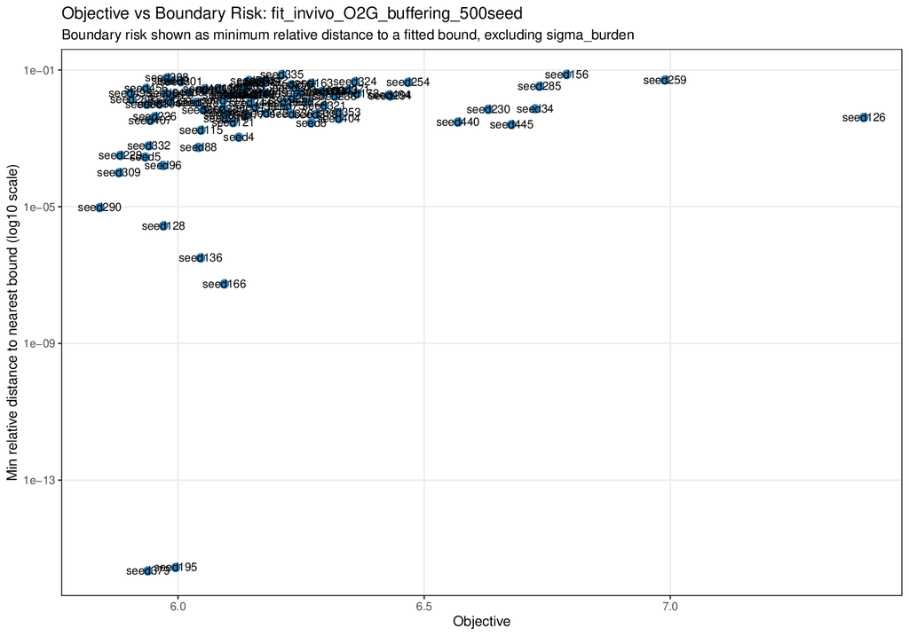

## Figure 1. Objective vs Boundary Risk

Objective score against minimum relative distance to the nearest fitted parameter bound.

`objective_vs_boundary_risk.pdf`

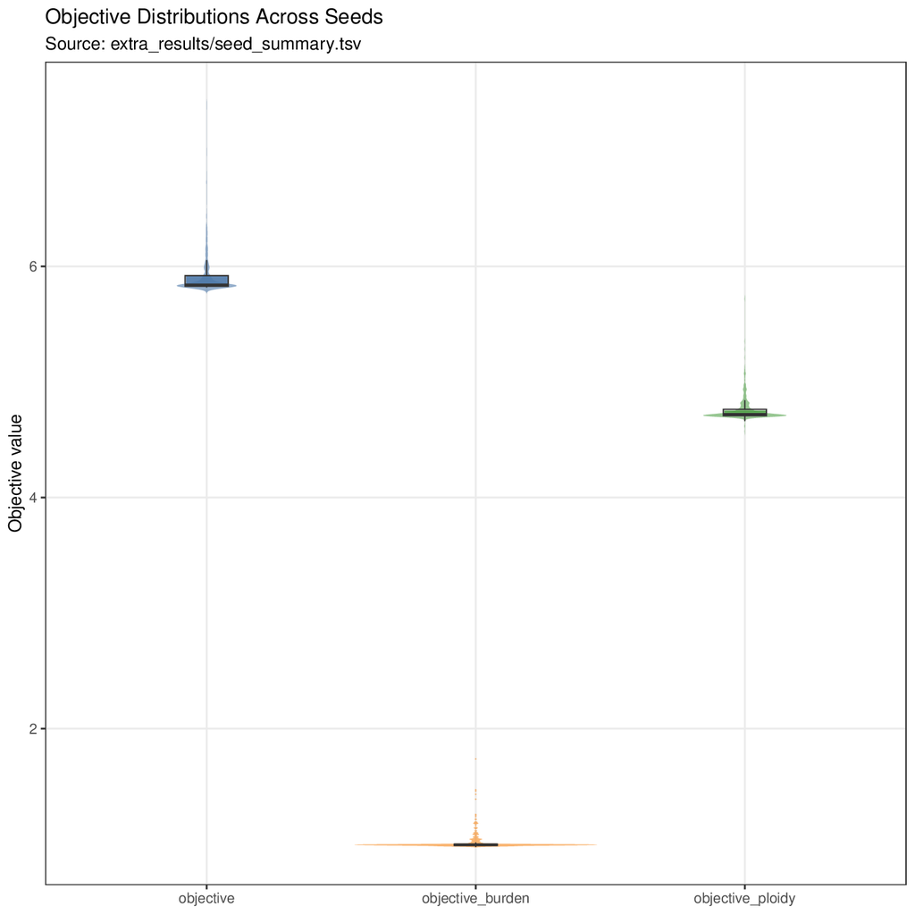

## Figure 2. Objective Components Violin

Across-seed distributions of total objective, burden objective, and ploidy objective.

`objective_components_violin.pdf`

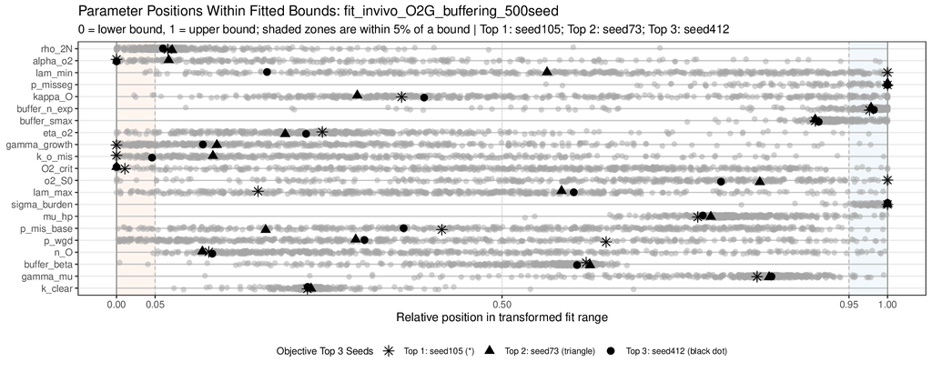

## Figure 3. Parameter Boundary Forest

Relative fitted positions of active parameters within their transformed bounds across all seeds. Highlighted seeds are the top 3 by raw objective.

`parameter_boundary_forest.pdf`

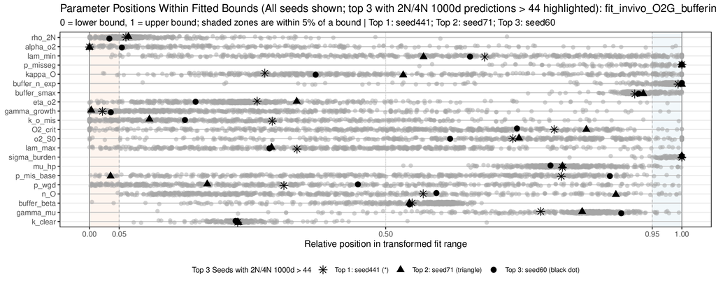

## Figure 4. Parameter Boundary Forest (Pred1000 > 44 Top 3)

Boundary forest shows all seeds; the highlighted seeds are the top eligible seeds. Eligibility requires all final 2N and 4N 1000-day predictions to be above 44; eligible seeds are ordered by raw objective. Top 1: seed441; Top 2: seed71; Top 3: seed60

`parameter_boundary_forest_pred1000_gt44_top3.pdf`

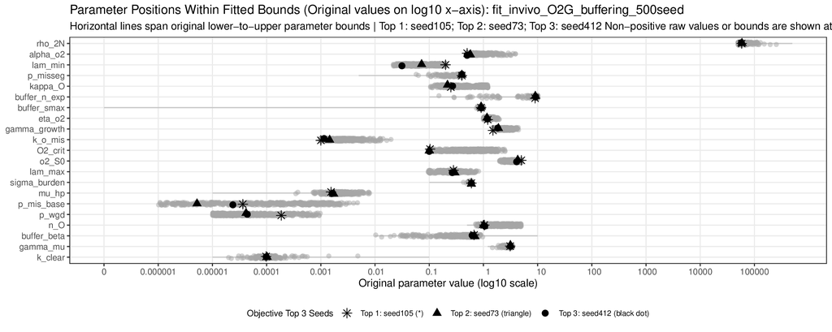

## Figure 5. Parameter Boundary Forest (Log X Scale)

Original fitted parameter values across all seeds on a log10 x-axis. Highlighted seeds are the top 3 by raw objective. Horizontal lines span original lower-to-upper parameter bounds; non-positive raw values or bounds are floored and labeled 0.

`parameter_boundary_forest_log_x.pdf`

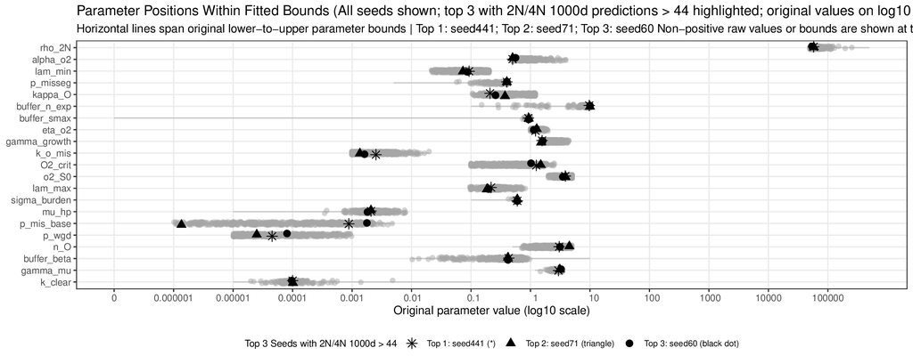

## Figure 6. Parameter Boundary Forest (Pred1000 > 44 Top 3, Log X Scale)

Boundary forest shows all seeds; the highlighted seeds are the top eligible seeds. Eligibility requires all final 2N and 4N 1000-day predictions to be above 44; eligible seeds are ordered by raw objective. Top 1: seed441; Top 2: seed71; Top 3: seed60 The x-axis shows original fitted parameter values on a log10 scale; non-positive raw values or bounds are floored and labeled 0.

`parameter_boundary_forest_pred1000_gt44_top3_log_x.pdf`

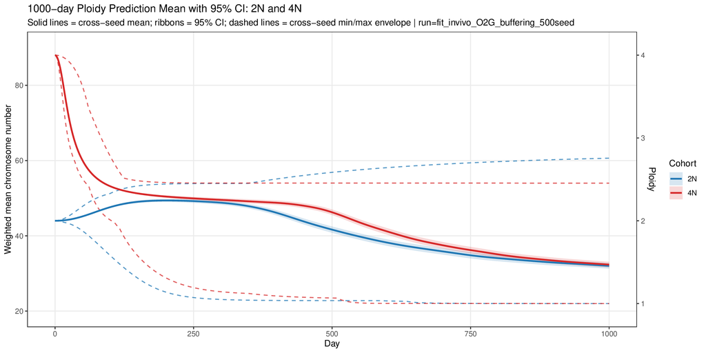

## Figure 7. Cross-seed 1000-day Ploidy Prediction: 2N and 4N

Mean trajectories and 95% confidence intervals across seed-level scenario means. Dashed lines show the cross-seed min/max envelope; the right y-axis reports ploidy.

`predict1000_ploidy_mean_ci_2N_4N.pdf`

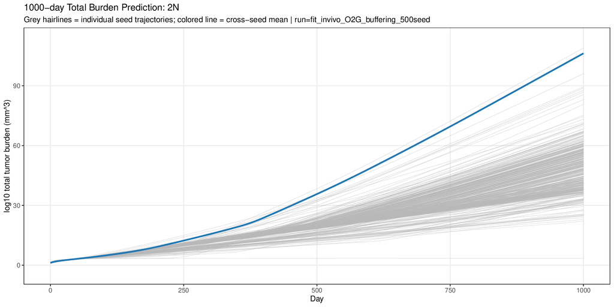

## Figure 8. Cross-seed 1000-day Total Burden Prediction: 2N

All seed-level scenario-mean total-burden trajectories are drawn as thin grey lines on the log10 scale. The colored solid line is the cross-seed mean.

`predict1000_burden_total_log_seed_mean_2N.pdf`

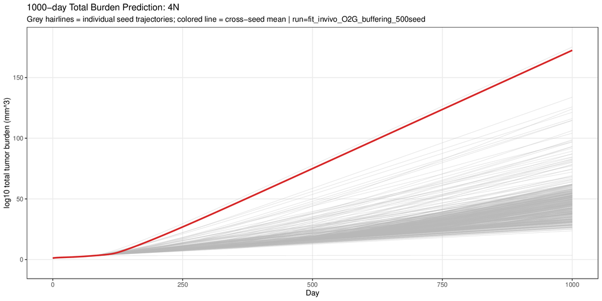

## Figure 9. Cross-seed 1000-day Total Burden Prediction: 4N

All seed-level scenario-mean total-burden trajectories are drawn as thin grey lines on the log10 scale. The colored solid line is the cross-seed mean.

`predict1000_burden_total_log_seed_mean_4N.pdf`

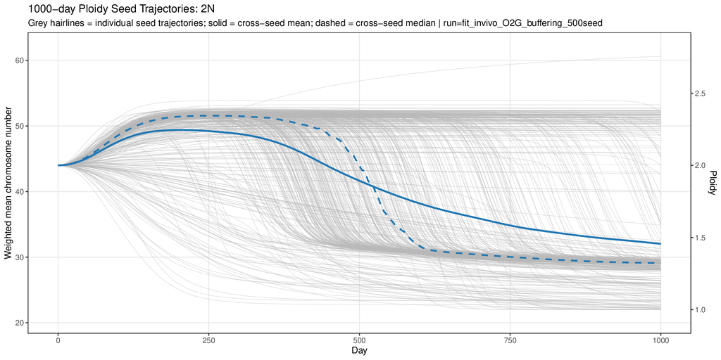

## Figure 10. Cross-seed 1000-day Ploidy Seed Trajectories: 2N

All seed-level scenario-mean trajectories are drawn as thin grey lines. The colored solid line is the cross-seed mean and the colored dashed line is the cross-seed median.

`predict1000_ploidy_seed_curves_2N.pdf`

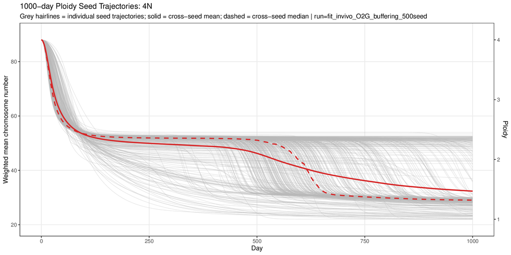

## Figure 11. Cross-seed 1000-day Ploidy Seed Trajectories: 4N

All seed-level scenario-mean trajectories are drawn as thin grey lines. The colored solid line is the cross-seed mean and the colored dashed line is the cross-seed median.

`predict1000_ploidy_seed_curves_4N.pdf`